# Homework 3

## Question 6

### Part A

```r
library(ROCR)
```

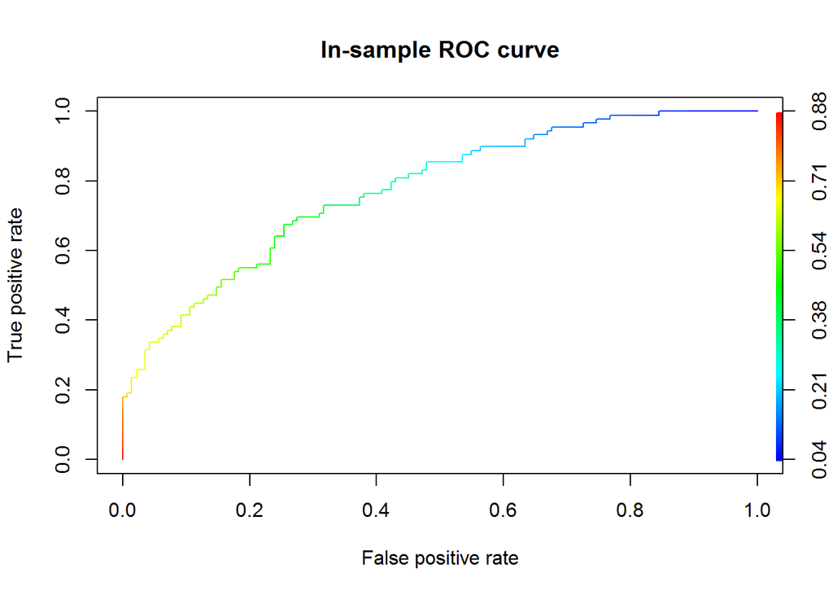

```r
# Logistic
scores <- predict(sa.heart.fit, newdata=train, type="response")

# compare predicted probabilities to labels, for varying probability cutoffs
pred <- prediction(scores, labels=train$chd )
perf <- performance(pred, "tpr", "fpr")

# plot the ROC curve
plot(perf, colorize=T, main="In-sample ROC curve")
```

```r
# print out the area under the curve
unlist(attributes(performance(pred, "auc"))$y.values)
```

```
## [1] 0.7757557
```

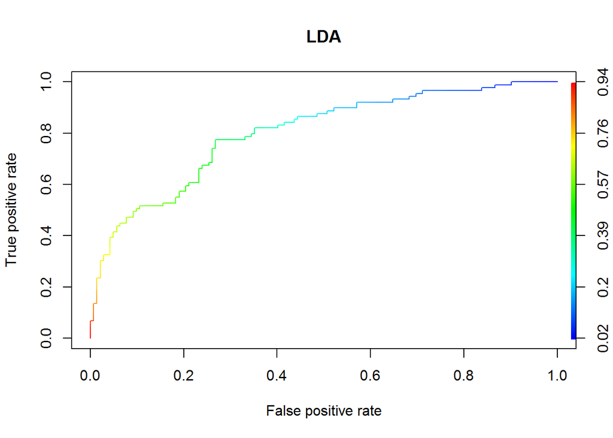

```r
#LDA
scores <- predict(lda.fit, newdata= train)$posterior[,2]
pred <- prediction( scores, labels= train$chd )
perf <- performance(pred, "tpr", "fpr")
plot(perf, colorize=T, main="LDA")
```

```r
# print out the area under the curve
unlist(attributes(performance(pred, "auc"))$y.values)
```

```
## [1] 0.8002057
```

```r
#Lasso
summary(lasso.fit)
```

```
##
## Call:
## glm(formula = chd ~ tobacco + ldl + famhist + typea + obesity +
##     age, family = binomial, data = train)
##
## Deviance Residuals:
##     Min       1Q   Median       3Q      Max
## -1.8657  -0.8132  -0.4169   0.8768   2.3527
##
## Coefficients:
##             Estimate Std. Error z value Pr(>|z|)
## (Intercept) -5.95245    1.55916  -3.818 0.000135 ***
## tobacco      0.07001    0.03680   1.903 0.057081 .
## ldl          0.31295    0.08703   3.596 0.000323 ***
## famhist      0.84793    0.31932   2.655 0.007921 **
## typea        0.03701    0.01760   2.103 0.035475 *
## obesity     -0.07713    0.04281  -1.802 0.071589 .
## age          0.05300    0.01504   3.524 0.000425 ***
## ---
## Signif. codes:  0 '***' 0.001 '**' 0.01 '*' 0.05 '.' 0.1 ' ' 1
##
## (Dispersion parameter for binomial family taken to be 1)
##
##     Null deviance: 307.96  on 230  degrees of freedom
## Residual deviance: 240.58  on 224  degrees of freedom
## AIC: 254.58
##
## Number of Fisher Scoring iterations: 4
```

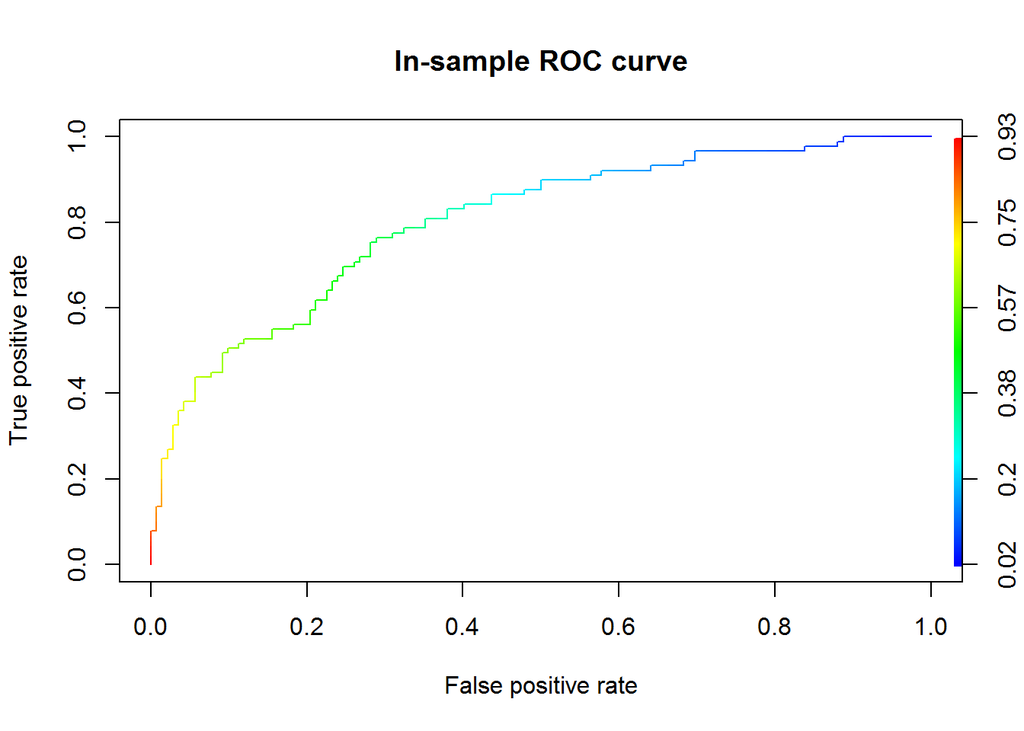

```r
# calculate predicted probabilities on the same training set
scores <- predict(lasso.fit, newdata=train, type="response")

# compare predicted probabilities to labels, for varying probability cutoffs
pred <- prediction(scores, labels=train$chd )
perf <- performance(pred, "tpr", "fpr")

# plot the ROC curve
plot(perf, colorize=T, main="In-sample ROC curve")
```

```r
# print out the area under the curve
unlist(attributes(performance(pred, "auc"))$y.values)
```

```
## [1] 0.8004431
```

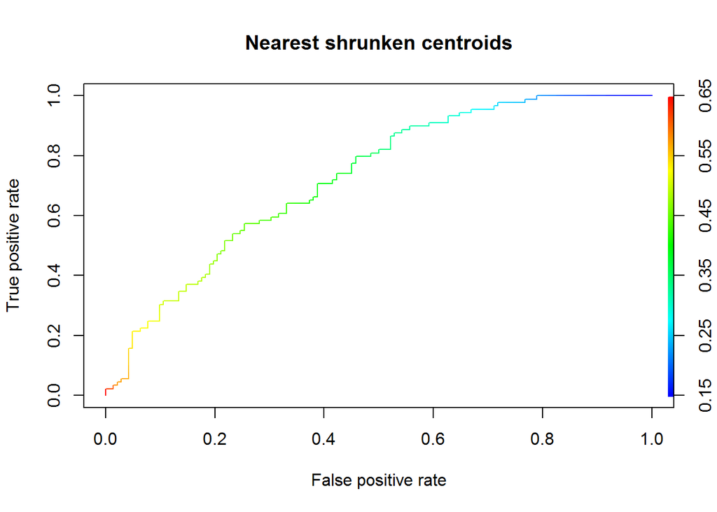

```r
# Nearest shrunken centroids
pred.pamr.train <- pamr.predict(fit.pamr, newx=pamrTrain$x, threshold=0.1367487, type="posterior")[,2]
pred <- prediction(predictions=pred.pamr.train, labels= pamrTrain$y)
perf <- performance(pred, "tpr", "fpr")
plot(perf, colorize=T, main="Nearest shrunken centroids")
```

```r
# print out the area under the curve
unlist(attributes(performance(pred, "auc"))$y.values)
```

```
## [1] 0.724007
```

### Part B

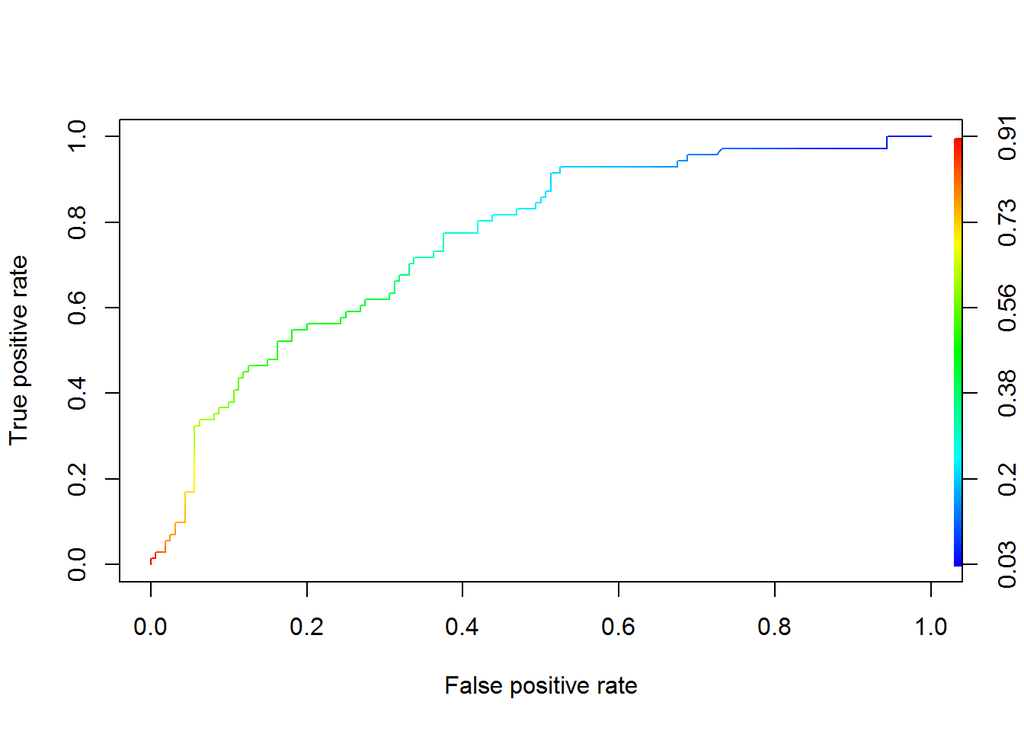

```r
#logistic
# make prediction on the validation dataset
scores <- predict(sa.heart.fit, newdata=valid, type="response")
pred <- prediction(scores, labels=valid$chd )
perf <- performance(pred, "tpr", "fpr")

# overlay the line for the ROC curve
plot(perf, colorize=T)
```

```r
# print out the area under the curve
unlist(attributes(performance(pred, "auc"))$y.values)
```

```
## [1] 0.7571743
```

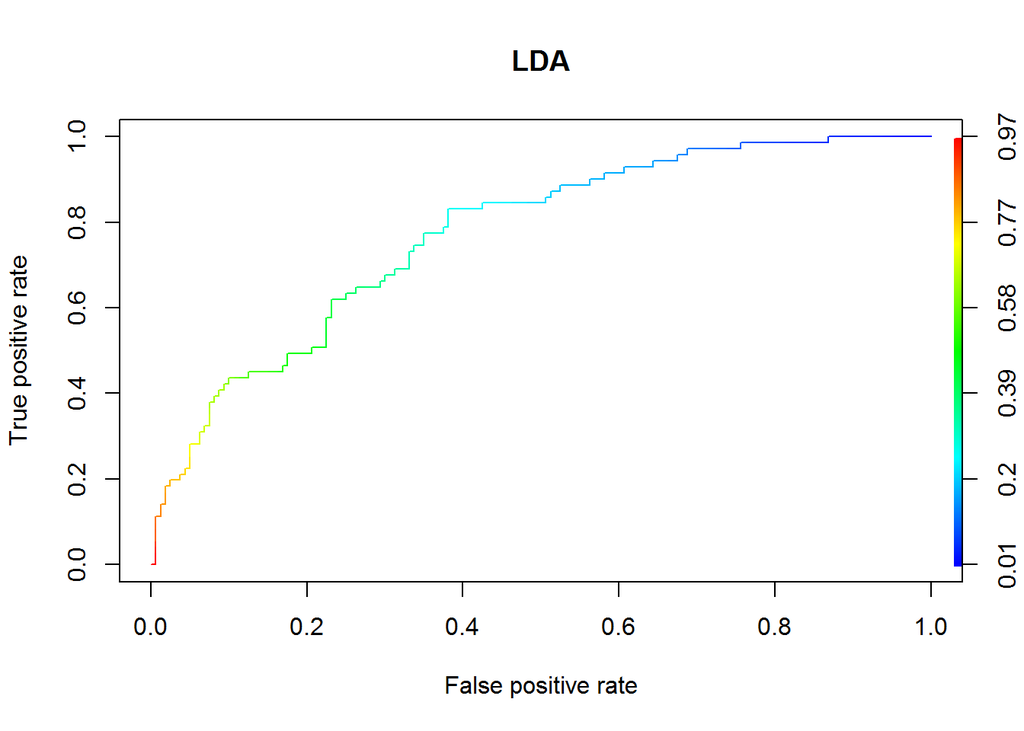

```r
# LDA
scores <- predict(lda.fit, newdata= valid)$posterior[,2]
pred <- prediction( scores, labels= valid$chd )
perf <- performance(pred, "tpr", "fpr")
plot(perf, colorize=T, main="LDA")
```

```r
# print out the area under the curve
unlist(attributes(performance(pred, "auc"))$y.values)
```

```
## [1] 0.7706866
```

```r
#Lasso
summary(lasso.fit)
```

```
##
## Call:
## glm(formula = chd ~ tobacco + ldl + famhist + typea + obesity +
##     age, family = binomial, data = train)
##
## Deviance Residuals:
##     Min       1Q   Median       3Q      Max
## -1.8657  -0.8132  -0.4169   0.8768   2.3527
##
## Coefficients:
##             Estimate Std. Error z value Pr(>|z|)
## (Intercept) -5.95245    1.55916  -3.818 0.000135 ***
## tobacco      0.07001    0.03680   1.903 0.057081 .
## ldl          0.31295    0.08703   3.596 0.000323 ***
## famhist      0.84793    0.31932   2.655 0.007921 **
## typea        0.03701    0.01760   2.103 0.035475 *
## obesity     -0.07713    0.04281  -1.802 0.071589 .
## age          0.05300    0.01504   3.524 0.000425 ***
## ---
## Signif. codes:  0 '***' 0.001 '**' 0.01 '*' 0.05 '.' 0.1 ' ' 1
##
## (Dispersion parameter for binomial family taken to be 1)
##
##     Null deviance: 307.96  on 230  degrees of freedom
## Residual deviance: 240.58  on 224  degrees of freedom
## AIC: 254.58
##
## Number of Fisher Scoring iterations: 4
```

[figure not shown]

```r
# calculate predicted probabilities on the same training set
scores <- predict(lasso.fit, newdata=valid, type="response")

# compare predicted probabilities to labels, for varying probability cutoffs
pred <- prediction(scores, labels=valid$chd )
perf <- performance(pred, "tpr", "fpr")

# plot the ROC curve
plot(perf, colorize=T, main="In-sample ROC curve")
```

```r
# print out the area under the curve
unlist(attributes(performance(pred, "auc"))$y.values)
```

```
## [1] 0.7751761
```

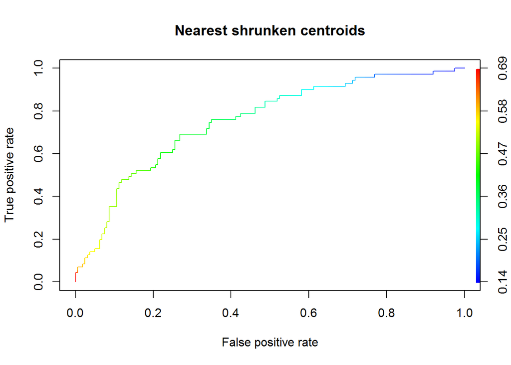

```r
# Nearest shrunken centroids
pred.pamr.train <- pamr.predict(fit.pamr, newx=pamrValid$x, threshold=0.1367487, type="posterior")[,2]
pred <- prediction(predictions=pred.pamr.train, labels= pamrValid$y)
perf <- performance(pred, "tpr", "fpr")
plot(perf, colorize=T, main="Nearest shrunken centroids")
```

```r
# print out the area under the curve
unlist(attributes(performance(pred, "auc"))$y.values)
```

```
## [1] 0.7525528
```

### Part C

After evaluating the ROC curve of each classifier, we can find the result between training and validation set are slightly different.

#### How do the results different between the training and the validation set?

On training set, the the area under the ROC curve:

- Logistic regression: 0.7757557
- LDA: 0.8002057
- Logistic with lasso: 0.8004431
- Nearest shrunken centroids: 0.724007

On valid set, the the area under the ROC curve:

- Logistic regression: 0.7571743
- LDA: 0.7706866
- Logistic with lasso: 0.7751761
- Nearest shrunken centroids: 0.7525528

#### Which approach(es) perform(s) better on the validation set?

In my experiment, LDA and Logistic with lasso performs a little bit better, but not too much. The best one (Logistic with lasso) and the worst one (Nearest shrunken centroids) only has 0.02 different in AUC.

#### What is are the reasons for this difference in performance?

They perform similar because this problem is a simple 2 class classification. I believe one of the reasons to cause them slightly different is the random training and validation dataset, they also perform differently on this problem.

- Logistic regression is not the best because we didn’t check the correlationship between predictors. And from the pair(train), we can see there are correlation between parameters.
- One drawback of diagonal LDA is that it depends on all of the features. This is the reason it can’t perform better in this problem.
- Logistic with Lasso is the best because it shrunk the dataset to filter out the less related predictors with zero coef. If we test different number of predictors, the result possibly become even better.
- Nearest shrunken centroids only depends on a subset of the features, for reasons of accuracy and interpret ability. With an accurate threshold with less err rate, it performs well in this problem.

#### Which models are more interpretable?

Firstly, LDA is not interpretable because it doesn’t apply subset selection. And Logistic with lasso and Nearest shrunk centroids are also both interpretable with small subset. And logistic with best subset selection can be the most interpretable if the selected subset is small. In this case, it is with 3 predictors.

## Question 7

- 1. GaussI <= LinLog LinLog is the logistic model maximizing the likelihoods
- 2. GaussX <= QuadLog Both of them have quadratic features, but QuadLog is the model of this class maximizing likelihoods
- 3. LinLog <= QuadLog LinLog with linear features is a subclass of QuadLog with quadratic functions
- 4. GaussI <= QuadLog GaussI have higher average log joint probabilities of examples and labels, but it does not necessarily translate to higher likelihoods. So QuadLog with quadratic functions maximizing the log likelihood may perform better.
- 5. It is commonly the case that GaussX <= GaussI and that QuadLog <= LinLog